# SGG - How does metadata relate to the microbiome?

André Soares

8 January 2018

## 1 - Visualizing SGG metadata

```r
sample_data(ps.b.r)$Site.name = factor(sample_data(ps.b.r)$Site.name,
                                          levels = c("Blaenavon","Cefn Hengoed","Mountain Gate","Taff Bargoed",
                                                     "Glyncastle","Dinas","Ynysarwed","Celynen North","Morlais",
                                                     "Lindsay","Six Bells","Crumlin Navigation","Taffs Well"))
metadata<-sample_data(ps.b.r)
#Temp
temp_table.plot<-ggplot(metadata,
                        aes(x=Site.name, y=Temp.C, fill=Month)) +
  geom_point(aes(fill=Month, color=Month),
             size=2,
             position = position_dodge(width=0.5)) +
  geom_hline(yintercept = 13.4,
             color="dark red",
             linetype="dashed") +
  geom_hline(yintercept = 11,
             color="gray",
             linetype="dashed") +
  theme(axis.title.x=element_blank(),
        axis.title.y = element_text(size=14),
        axis.text.x = element_blank(),
        axis.text.y = element_text(size=12),
        legend.position = "bottom",
        legend.title = element_text(face = "bold"),
        legend.background = element_rect(fill="gray95", size=.5, linetype="dotted")) +
  annotate("text", "Mountain Gate", 14, vjust = -1, hjust=.45, size= 4,
           label = "Average mine water temperature (Farr et al, 2016)") +
  labs(y=expression(paste("Temperature (",degree,"C)")))
#DO
do.plot<-ggplot(metadata,
                        aes(x=Site.name, y=`DO..sat`, fill=Month)) +
  geom_point(aes(fill=Month, color=Month),
             size=2,
             position = position_dodge(width=0.5)) +
  geom_line(aes(group=Month, color=Month),
            stat="smooth", method="loess",
            alpha = 0.4, size=1.5) +
  geom_hline(yintercept = 50,
           color="gray60",
           linetype="dashed") +
  theme(axis.title.x=element_blank(),
        axis.title.y = element_text(size=14),
        axis.text.x = element_blank(),
        axis.text.y = element_text(size=12),
        legend.position = "none") +
  labs(y="Dissolved Oxygen (%)")
#Sulfate
so4.plot<-ggplot(metadata,
                        aes(x=Site.name, y=`SO4..µg.ml`, fill=Month)) +
  geom_point(aes(fill=Month, color=Month),
             size=2,
             position = position_dodge(width=0.5)) +
  geom_line(aes(group=Month, color=Month),
            stat="smooth", method="loess",
            alpha = 0.4, size=1.5) +
  geom_hline(yintercept = 500,
         color="gray60",
         linetype="dashed") +
  theme(axis.title.x=element_blank(),
        axis.title.y = element_text(size=14),
        axis.text.x = element_blank(),
        axis.text.y = element_text(size=12),
        legend.position = "none") +
  labs(y=expression(paste("SO"[4]^{-2},"(",mu,"g.mL"^{-1},")"))) +
  guides(size=FALSE)
#pH
pH.plot<-ggplot(metadata,
                        aes(x=Site.name, y=`pH`, fill=Month)) +
  geom_point(aes(fill=Month, color=Month),
             size=2,
             position = position_dodge(width=0.5)) +
  geom_line(aes(group=Month, color=Month),
            stat="smooth", method="loess",
            alpha = 0.4, size=1.5) +
  geom_hline(yintercept = 7,
           color="gray60",
           linetype="dashed") +
  theme(axis.title.x=element_blank(),
        axis.title.y = element_text(size=14),
        axis.text.x = element_blank(),
        axis.text.y = element_text(size=12),
        legend.position = "none") +
  labs(y="pH") +
  guides(size=FALSE)
#EC
ec.plot<-ggplot(metadata,
                        aes(x=Site.name, y=`EC.uS.cm`, fill=Month)) +
  geom_point(aes(fill=Month, color=Month),
             size=2,
             position = position_dodge(width=0.5)) +
  geom_line(aes(group=Month, color=Month),
            stat="smooth", method="loess",
            alpha = 0.4, size=1.5) +
  geom_hline(yintercept = 2000,
           color="gray60",
           linetype="dashed") +
  geom_hline(yintercept = 1000,
           color="grey80",
           linetype="dashed") +
  scale_y_continuous(breaks=c(0,500,1000,1500,2000,2500,3000)) +
  theme(axis.title.x=element_blank(),
        axis.title.y = element_text(size=14),
        axis.text.x = element_text(angle = 25, hjust = 1, size= 14),
        axis.text.y = element_text(size=12),
        legend.position = "top",
        legend.title = element_text(face = "bold"),
        legend.background = element_rect(fill="gray95", size=.5, linetype="dotted")) +
  labs(y=expression(paste("EC (",mu,"S.cm"^{-1},")")))
```

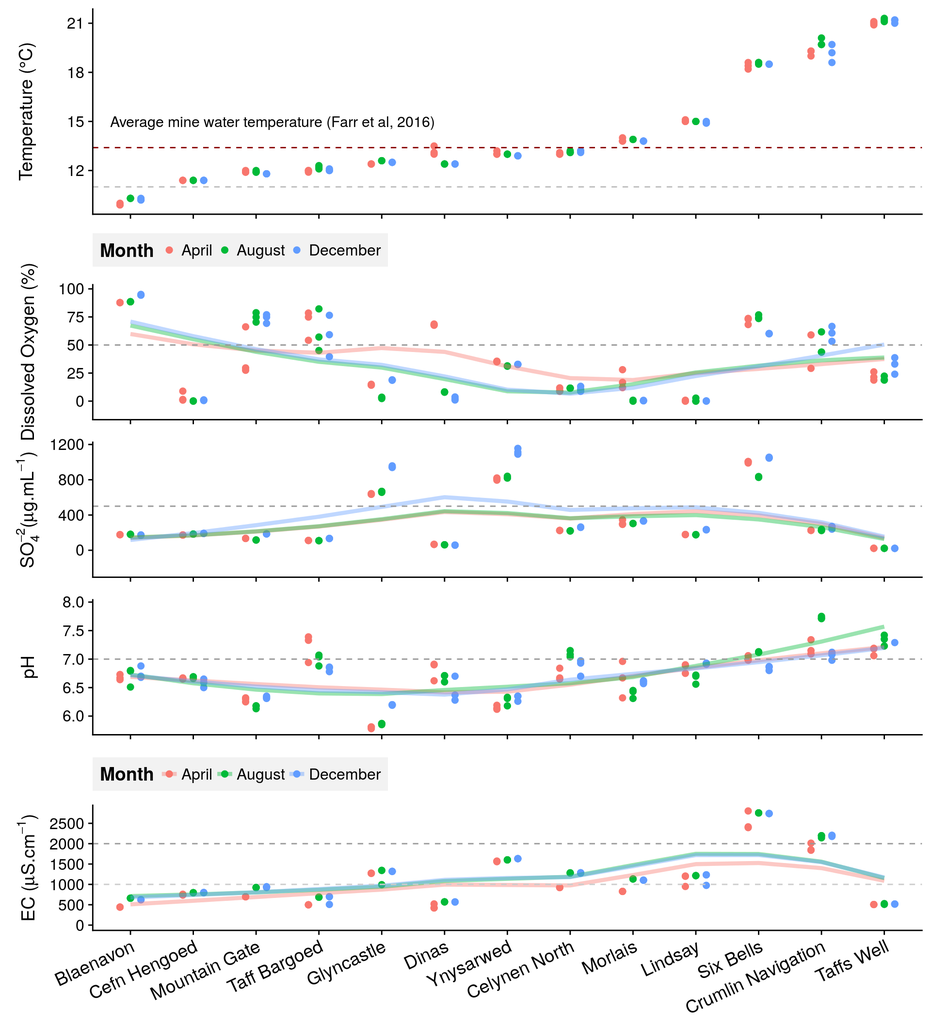

```r
plot_grid(temp_table.plot, do.plot, so4.plot, pH.plot, ec.plot, ncol = 1, align='v', rel_heights = c(1.75,1,1,1,1.75))
```

And does SO4 coincide ‘more or less’ negatively correlate with DO just to make sure?

```r
do.so4.plot<-ggplot(metadata,
                        aes(x=Site.name)) +
  geom_point(aes(y=`DO..sat`,
                 fill="Dissolved Oxygen", color="Dissolved Oxygen",
                 shape=Month),
             size=2,
             position = position_dodge(width=0.5)) +
  geom_point(aes(y=`SO4..µg.ml`/12,
                 fill="Sulfate", color="Sulfate",
                 shape=Month),
             size=2,
             position = position_dodge(width=0.5)) +
  geom_line(aes(y=`DO..sat`,
                group=Month,
                color="Dissolved Oxygen"),
            stat="smooth", method="loess",
            alpha = 0.4, size=1.5) +
  geom_line(aes(y=`SO4..µg.ml`/12,
                group=Month,
                color="Sulfate"),
        stat="smooth", method="loess",
        alpha = 0.4, size=1.5) +
  scale_colour_manual(values = c("dodgerblue1", "firebrick2")) +
  scale_y_continuous(sec.axis = sec_axis(~.*12, name = expression(paste("SO"[4]^{-2},"(",mu,"g.mL"^{-1},")")))) +
  labs(y="Dissolved Oxygen (%)",
       colour = "Parameter") +
  theme(axis.title.x=element_blank(),
        axis.title.y = element_text(size=14),
        axis.text.x = element_text(angle=35, hjust = 1,vjust = 1),
        axis.text.y = element_text(size=12),
        legend.position = "top",
        legend.justification = "center",
        legend.text = element_text(size = 12),
        legend.title = element_text(size = 13, face = "bold"),
        legend.direction = "vertical") +
  guides(fill = FALSE)
```

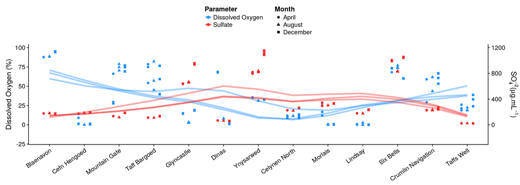

```r
do.so4.plot
```

Yep-ish.

But how does the overal picture look regarding how variables relate to one another?

```r
#remove all columns with one or more NA entry
#NA in DO substituted to the mean of the two values in the site
sgg_metadata<-as(sample_data(ps.b.r),"data.frame")
sgg_metadata$DO..sat[is.na(sgg_metadata$DO..sat)] <- 44.1
sgg_metadata_noNA = sgg_metadata[ , colSums(is.na(sgg_metadata)) == 0]
colnames(sgg_metadata_noNA) <- c("Sample_Code","Sample.ID","Sample_type","Site.ID","Site.name","Time_point","Month","Batch","Date", "Time",
                                 "Temperature","EC","DO","K","Na","Cl","SO4","6_Li","7_Li","7_Li_He","B","Sc","Mn","Co","Ni","Ga","As","Se",
                                 "Rb","Sr","Y","Te","Cs","Ba","La","Nd","Eu","Er","Lu","U")
sgg_metadata_noNA_april<-subset(sgg_metadata_noNA,
                                                  Month %in% c("April"))
sgg_metadata_noNA_august<-subset(sgg_metadata_noNA,
                                                  Month %in% c("August"))
sgg_metadata_noNA_december<-subset(sgg_metadata_noNA,
                                                  Month %in% c("December"))
cols_to_go_april <- names(sgg_metadata_noNA_april) %in% c("Sample_Code", "Sample.ID", "Sample_type","Site.ID",
                                                "Site.name","Time_point","Month","Batch",
                               "Date","Time")
cols_to_go_august <- names(sgg_metadata_noNA_august) %in% c("Sample_Code", "Sample.ID", "Sample_type","Site.ID",
                                                        "Site.name","Time_point","Month","Batch",
                               "Date","Time")
cols_to_go_december <- names(sgg_metadata_noNA_december) %in% c("Sample_Code", "Sample.ID", "Sample_type","Site.ID",
                                                            "Site.name","Time_point","Month","Batch",
                               "Date","Time")
sgg_metadata_noNA_april_f <- sgg_metadata_noNA_april[!cols_to_go_april]
sgg_metadata_noNA_august_f <- sgg_metadata_noNA_august[!cols_to_go_august]
sgg_metadata_noNA_december_f <- sgg_metadata_noNA_december[!cols_to_go_december]

april_corr<-ggcorr(sgg_metadata_noNA_april_f, method = c("all.obs", "spearman"),
                   palette = "RdBu",
                   nbreaks = 10, hjust = 1,
                   size=4, layout.exp = 6) +
                   ggtitle("April")
august_corr<-ggcorr(sgg_metadata_noNA_august_f, method = c("all.obs", "spearman"),
                    palette = "RdBu",
                    nbreaks = 10, hjust = 1,
                    size=4, layout.exp = 6) +
                    ggtitle("August")
december_corr<-ggcorr(sgg_metadata_noNA_december_f, method = c("all.obs", "spearman"),
                      palette = "RdBu",
                      nbreaks = 10, hjust = 1,
                      size=4, layout.exp = 6) +
                      ggtitle("December")
```

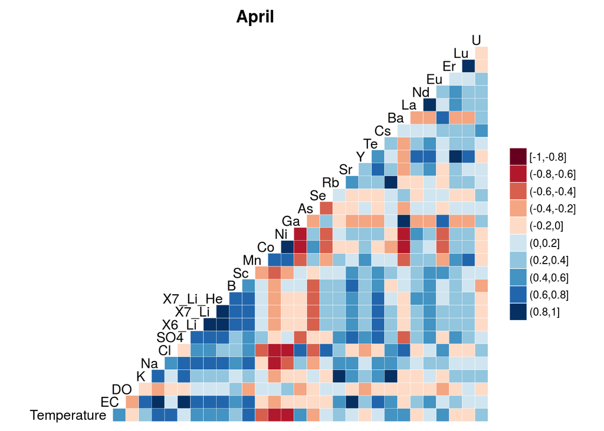

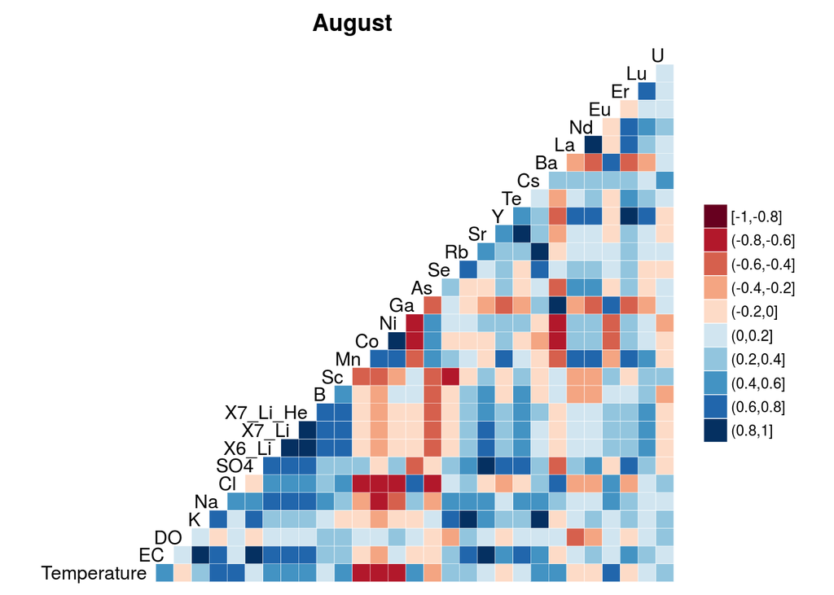

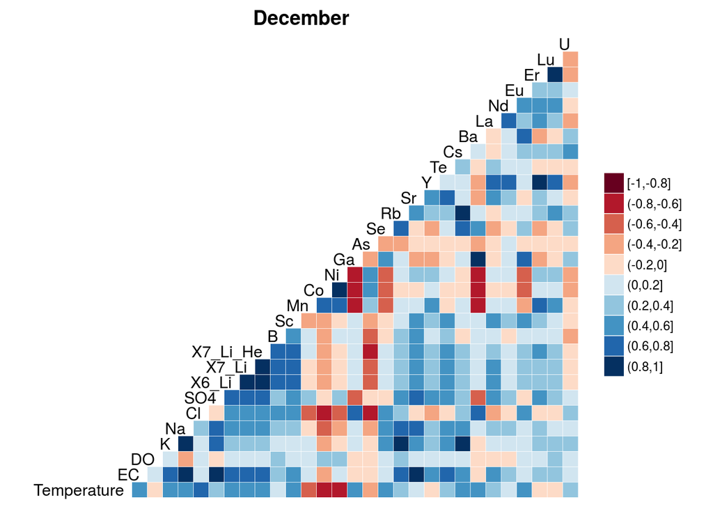

*Pearson* assumes linearity between variables as well as normal distributions of data and is sensible to transformation. *Spearman* is a nonparametric measure of rank correlation as *Kendall* is, meaning they don’t care about transformations. *Kendall* meaures strength of dependence between two variables. *Spearman* does not make assumptions of data distribution and measures degree of association between two variables.

There’s clearly a lot of variation, but definitely there’s loads more to learn on how these variables relate.

## 2 - Does SGG Sulfate data coincide with Coal Authority data from previous years?

```r
swales_ca_metadata<-read.csv("/media/andre/B2F8C9A0F8C962E9/SGG_16S_analysis/SGG_16S_metadata/R_previous_BGS_chem_data_SWales.csv", header=TRUE)
swales_ca_metadata$Site = factor(swales_ca_metadata$Site,
                                          levels = c("Blaenavon","Cefn Hengoed","Mountain Gate","Taff Bargoed",
                                                     "Glyncastle","Dinas","Ynysarwed","Celynen North","Morlais",
                                                     "Lindsay","Six Bells","Crumlin Navigation","Taffs Well"))
swales_ca_metadata$Month = factor(swales_ca_metadata$Month,
                                          levels = c("January","February","March","April","May","June","July",
                                                     "August","September","October","November","December"))
#Sulfate from CA
swales_ca_metadata_plot<-ggplot(swales_ca_metadata,
                        aes(x=Site, y=`SO4.ug.mL`, fill=Month)) +
  geom_point(aes(fill=Month, color=Month),
             size=2,
             position = position_dodge(width=0.5)) +
  facet_wrap(~Year, ncol = 1) +
  theme(axis.title.x=element_blank(),
        axis.title.y = element_text(size=14),
        axis.text.x = element_text(angle = 35, hjust = 1, vjust = 1),
        axis.text.y = element_text(size=12),
        legend.position = "bottom",
        legend.justification = "center",
        legend.text=element_text(size=7)) +
  guides(fill = guide_legend(nrow = 1),
         color = guide_legend(nrow = 1)) +
  scale_y_continuous(expand = c(0,0)) +
  labs(y=expression(paste("SO"[4]^{-2},"(",mu,"g.mL"^{-1},")")))

swales_ca_metadata_2016<-subset(swales_ca_metadata,
                                                  Year %in% c("2016"))

swales_ca_metadata_2016_plot<-ggplot(swales_ca_metadata_2016,
                        aes(x=Site, y=`SO4.ug.mL`, fill=Month)) +
  geom_point(aes(fill=Month, color=Month),
             size=2,
             position = position_dodge(width=0.5)) +
  theme(axis.title.x=element_blank(),
        axis.title.y = element_text(size=14),
        axis.text.x = element_text(angle = 25, hjust = 1, vjust = 1, size= 12),
        axis.text.y = element_text(size=12),
        legend.position = "bottom",
        legend.justification = "center",
        legend.text=element_text(size=8)) +
  guides(fill = guide_legend(nrow = 1),
         color = guide_legend(nrow = 1)) +
  scale_y_continuous(breaks = c(0,250,500,750,1000)) +
  labs(y=expression(paste("SO"[4]^{-2},"(",mu,"g.mL"^{-1},")"))) +
  ggtitle("CA data - 2016")

#quick prep of our own data
so4.plot.cowplot=so4.plot +
  theme(legend.position = "bottom",
        legend.justification = "center",
        axis.text.x = element_text(angle = 25, hjust = 1, size= 12)) +
  scale_y_continuous(breaks = c(0,250,500,750,1000,1250)) +
  ggtitle("SGG data - 2016")
```

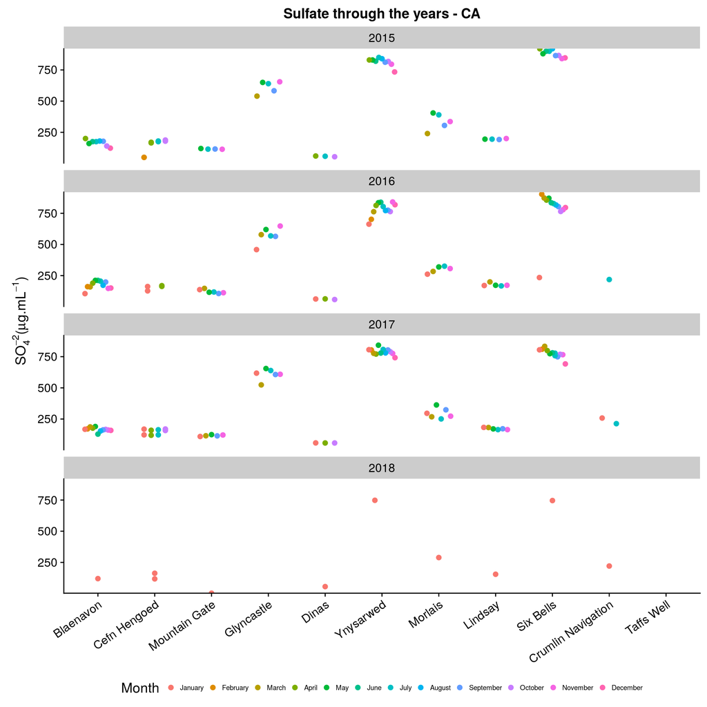

```r
swales_ca_metadata_plot + ggtitle("Sulfate through the years - CA")
```

How does CA’s 2016 data compare with ours though?

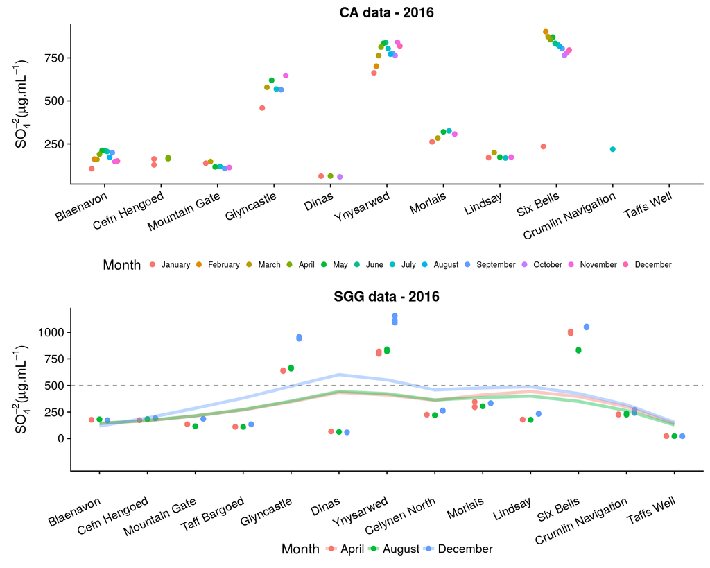

```r
plot_grid(swales_ca_metadata_2016_plot, so4.plot.cowplot,
          align = 'v', ncol = 1)
```

## 3 -According to CA data, how did iron do across our sites in 2016?

```r
iron_theme=theme(
        axis.title.x=element_blank(),
        axis.text.x = element_text(angle = 25, hjust = 1, vjust = 1, size= 12),
        axis.text.y = element_text(size=8),
        axis.title.y = element_text(angle = 0, size=10),
        legend.title = element_text(size=9, face = "bold"))

KONEFE_Fe_mgL_plot<-ggplot(swales_ca_metadata_2016,
                        aes(x=Site, y=`KONEFE_Fe_mgL`, fill=Month)) +
  geom_point(aes(fill=Month, color=Month),
             size=2,
             position = position_dodge(width=0.5)) +
  guides(fill = guide_legend(nrow = 1),
         color = guide_legend(nrow = 1)) +
  labs(y=expression(atop("KONEFE Iron as Fe",paste("(mg.L"^{-1},")")))) +
  iron_theme +
  theme(legend.position = "bottom",
        legend.justification = "left",
        legend.text=element_text(size=9),
        axis.text.x = element_blank())

D_Fe_mgL_plot<-ggplot(swales_ca_metadata_2016,
                        aes(x=Site, y=`D_Fe_mgL`, fill=Month)) +
  geom_point(aes(fill=Month, color=Month),
             size=2,
             position = position_dodge(width=0.5)) +
  guides(fill = guide_legend(nrow = 1),
         color = guide_legend(nrow = 1)) +
  labs(y=expression(atop("Iron as Fe (Dissolved)", paste("(mg.L"^{-1},")")))) +
  iron_theme +
  theme(legend.position = "none",
        axis.text.x = element_blank())

ICPWATVAR_Fe_mgL_plot<-ggplot(swales_ca_metadata_2016,
                        aes(x=Site, y=`ICPWATVAR_Fe_mgL`, fill=Month)) +
  geom_point(aes(fill=Month, color=Month),
             size=2,
             position = position_dodge(width=0.5)) +
  guides(fill = guide_legend(nrow = 1),
         color = guide_legend(nrow = 1)) +
  labs(y=expression(atop("Iron as Fe (Total) ICPWATVAR", paste("(mg.L"^{-1},")")))) +
  iron_theme +
  theme(legend.position = "bottom",
        legend.justification = "left",
        legend.text=element_text(size=9),
        axis.text.x = element_blank())

Fe2_mgL_plot<-ggplot(swales_ca_metadata_2016,
                        aes(x=Site, y=`Fe2_mgL`, fill=Month)) +
  geom_point(aes(fill=Month, color=Month),
             size=2,
             position = position_dodge(width=0.5)) +
  guides(fill = guide_legend(nrow = 1),
         color = guide_legend(nrow = 1)) +
  labs(y=expression(atop("Ferrous Iron as Fe"^{2+""}, paste("(mg.L"^{-1},")")))) +
  iron_theme +
  theme(legend.position = "none")
```

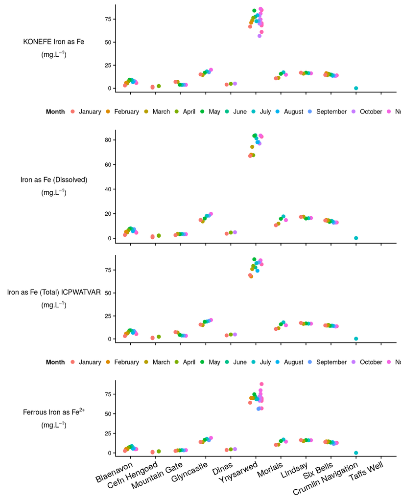

```r
plot_grid(KONEFE_Fe_mgL_plot, D_Fe_mgL_plot, ICPWATVAR_Fe_mgL_plot, Fe2_mgL_plot,
          align = 'v', ncol = 1,
          rel_heights = c(0.1,0.1,0.1,0.1))
```

So, in 2016, while most of the other sites were close to 0, it seems a LOT of iron was being detected in Ynysarwed. Are there taxonomical evidences of more iron users there? Not really as seen on `SGG-GenTaxonomy.html`.

## 4 - How do environmental variables relate to microbial community structure in this dataset?

An `adonis` test tests “how is variation attributed to different experimental” variables, using distance matrices. It analyses how variables can be sources of variation of distance matrices and depends on fitting linear models to distance matrices. AKA PERMANOVA.

*Null hypothesis:* tested metadata categories have the same centroid.

```r
metadata<-as(sample_data(ps.b.r),"data.frame")
metadata$DO..sat[is.na(metadata$DO..sat)] <- 44.1
metadata_noNA = metadata[ , colSums(is.na(metadata)) == 0]

ps_sig <- phyloseq(otu_table(SGG_SVt, taxa_are_rows=FALSE),
                   sample_data(metadata_noNA),
                   tax_table(SGG_Tax))
sample_data(ps_sig)$Month = factor(sample_data(ps_sig)$Month,
                                   levels = c("April","August","December","Control"))
ps_sig_ntf = subset_samples(ps_sig, Site.name != "Taffs Well PUMPED")
ps_sig_ntf_nc = subset_samples(ps_sig_ntf, Sample_type != "Control")
ps_sig_ntf_nc_noab = subset_taxa(ps_sig_ntf_nc, Kingdom %in% c("Archaea", "Bacteria"))
ps_cap_r = transform_sample_counts(ps_sig_ntf_nc_noab, function(x) x/sum(x))

set.seed(1)
# Calculate Jensen-Shannon distance matrix
ps_cap_r_jsd <- phyloseq::distance(ps_cap_r, method = "jsd")
# make a data frame from the sample_data
sampledf_cap <- data.frame(sample_data(ps_cap_r))

adonis(ps_cap_r_jsd ~ Site.name + Temp.C + Month + EC.uS.cm + DO..sat + K.µg.ml + Na.µg.ml + Cl..µg.ml + SO4..µg.ml + X6.Li.ng.ml + X7.Li.ng.ml + X7.Li..He..ng.ml + X11.B.ng.ml + X45.Sc.ng.ml + X55.Mn.ng.ml + X59.Co.ng.ml + X60.Ni.ng.ml + X69.Ga.ng.ml + X75.As..He..ng.ml + X78.Se.ng.ml + X85.Rb.ng.ml + X88.Sr.ng.ml + X89.Y.ng.ml + X125.Te.ng.ml + X133.Cs.ng.ml + X135.Ba.ng.ml + X139.La.ng.ml + X146.Nd.ng.ml + X153.Eu.ng.ml + X166.Er.ng.ml + X175.Lu.ng.ml + X238.U.ng.ml,
       data = sampledf_cap, strata = sampledf_cap$Time_point, permutations=1e3)
```

```
##
## Call:
## adonis(formula = ps_cap_r_jsd ~ Site.name + Temp.C + Month +      EC.uS.cm + DO..sat + K.µg.ml + Na.µg.ml + Cl..µg.ml +      SO4..µg.ml + X6.Li.ng.ml + X7.Li.ng.ml + X7.Li..He..ng.ml +      X11.B.ng.ml + X45.Sc.ng.ml + X55.Mn.ng.ml + X59.Co.ng.ml +      X60.Ni.ng.ml + X69.Ga.ng.ml + X75.As..He..n…
##
## Blocks:  strata
## Permutation: free
## Number of permutations: 1000
##
## Terms added sequentially (first to last)
##
##                    Df SumsOfSqs MeanSqs F.Model      R2   Pr(>F)
## Site.name          12   17.2135 1.43446  56.971 0.82991 0.000999 ***
## Temp.C              1    0.1026 0.10264   4.076 0.00495 0.000999 ***
## Month               2    0.1955 0.09774   3.882 0.00942 0.000999 ***
## EC.uS.cm            1    0.0528 0.05277   2.096 0.00254 0.020979 *
## DO..sat             1    0.0989 0.09888   3.927 0.00477 0.000999 ***
## K.µg.ml             1    0.0356 0.03561   1.414 0.00172 0.174825
## Na.µg.ml            1    0.0390 0.03897   1.548 0.00188 0.108891
## Cl..µg.ml           1    0.1391 0.13907   5.523 0.00670 0.000999 ***
## SO4..µg.ml          1    0.0638 0.06384   2.535 0.00308 0.011988 *
## X6.Li.ng.ml         1    0.0482 0.04822   1.915 0.00232 0.039960 *
## X7.Li.ng.ml         1    0.0404 0.04041   1.605 0.00195 0.087912 .
## X7.Li..He..ng.ml    1    0.0187 0.01868   0.742 0.00090 0.685315
## X11.B.ng.ml         1    0.0280 0.02796   1.111 0.00135 0.359640
## X45.Sc.ng.ml        1    0.0492 0.04917   1.953 0.00237 0.044955 *
## X55.Mn.ng.ml        1    0.0833 0.08326   3.307 0.00401 0.001998 **
## X59.Co.ng.ml        1    0.0429 0.04287   1.703 0.00207 0.086913 .
## X60.Ni.ng.ml        1    0.0468 0.04678   1.858 0.00226 0.056943 .
## X69.Ga.ng.ml        1    0.0192 0.01919   0.762 0.00093 0.689311
## X75.As..He..ng.ml   1    0.0325 0.03249   1.290 0.00157 0.223776
## X78.Se.ng.ml        1    0.0364 0.03640   1.446 0.00176 0.165834
## X85.Rb.ng.ml        1    0.0564 0.05639   2.240 0.00272 0.015984 *
## X88.Sr.ng.ml        1    0.0360 0.03599   1.429 0.00174 0.156843
## X89.Y.ng.ml         1    0.1430 0.14302   5.680 0.00690 0.000999 ***
## X125.Te.ng.ml       1    0.0204 0.02038   0.809 0.00098 0.642358
## X133.Cs.ng.ml       1    0.0140 0.01401   0.557 0.00068 0.874126
## X135.Ba.ng.ml       1    0.0406 0.04056   1.611 0.00196 0.100899
## X139.La.ng.ml       1    0.1084 0.10840   4.305 0.00523 0.000999 ***
## X146.Nd.ng.ml       1    0.0288 0.02881   1.144 0.00139 0.297702
## X153.Eu.ng.ml       1    0.0219 0.02194   0.871 0.00106 0.544456
## X166.Er.ng.ml       1    0.0188 0.01884   0.748 0.00091 0.710290
## X175.Lu.ng.ml       1    0.0171 0.01708   0.678 0.00082 0.727273
## X238.U.ng.ml        1    0.0369 0.03685   1.464 0.00178 0.125874
## Residuals          72    1.8129 0.02518         0.08740
## Total             116   20.7414                 1.00000
## ---
## Signif. codes:  0 '***' 0.001 '**' 0.01 '*' 0.05 '.' 0.1 ' ' 1
```

Site ID significantly explains >80% of the variation. Does this change with a normalised metadata table?

```r
norm_metadata<-read.csv("/media/andre/B2F8C9A0F8C962E9/SGG_16S_analysis/SGG_16S_metadata/SGG_metadata_norm.csv", header=TRUE)
#does this change with a normalised metadata table?
normalize <- function(x) {
    return ((x - min(x)) / (max(x) - min(x)))
}
norm_metadata$Sample_Code<-as.numeric(norm_metadata$Sample_Code)
norm_metadata_s <- norm_metadata[order(norm_metadata$Sample_Code),]
norm_metadata_s$DO..sat[is.na(norm_metadata_s$DO..sat)] <- 44.1
sampledf_cap_norm <- as.data.frame(lapply(norm_metadata_s, normalize))
sampledf_cap_norm_noNA = sampledf_cap_norm[ , colSums(is.na(sampledf_cap_norm)) == 0]
#remove Sample_Code, substitute with originals
cols_to_go_sampledf_cap_norm_noNA <- names(sampledf_cap_norm_noNA) %in% c("Sample_Code")
sampledf_cap_norm_noNA_f <- sampledf_cap_norm_noNA[!cols_to_go_sampledf_cap_norm_noNA]
sampledf_cap_norm_noNA_f$Sample_Code <- norm_metadata_s$Sample_Code
sampledf_cap_norm_noNA_f <- sampledf_cap_norm_noNA_f %>% select(Sample_Code, everything())

order_jsd<-labels(ps_cap_r_jsd)
sampledf_cap_norm_noNA_f_ord<-sampledf_cap_norm_noNA_f[match(order_jsd, sampledf_cap_norm_noNA_f$Sample_Code),]
rownames(sampledf_cap_norm_noNA_f_ord) <- sampledf_cap_norm_noNA_f_ord$Sample_Code

adonis(ps_cap_r_jsd ~ Site.ID + Temp.C + Month + EC.uS.cm + DO..sat + K.µg.ml + Na.µg.ml + Cl..µg.ml + SO4..µg.ml + X6.Li.ng.ml + X7.Li.ng.ml + X7.Li..He..ng.ml + X11.B.ng.ml + X45.Sc.ng.ml + X55.Mn.ng.ml + X59.Co.ng.ml + X60.Ni.ng.ml + X69.Ga.ng.ml + X75.As..He..ng.ml + X78.Se.ng.ml + X85.Rb.ng.ml + X88.Sr.ng.ml + X89.Y.ng.ml + X125.Te.ng.ml + X133.Cs.ng.ml + X135.Ba.ng.ml + X139.La.ng.ml + X146.Nd.ng.ml + X153.Eu.ng.ml + X166.Er.ng.ml + X175.Lu.ng.ml + X238.U.ng.ml,
       data = sampledf_cap_norm_noNA_f_ord, permutations=1e3)
```

```
##
## Call:
## adonis(formula = ps_cap_r_jsd ~ Site.ID + Temp.C + Month + EC.uS.cm +      DO..sat + K.µg.ml + Na.µg.ml + Cl..µg.ml + SO4..µg.ml +      X6.Li.ng.ml + X7.Li.ng.ml + X7.Li..He..ng.ml + X11.B.ng.ml +      X45.Sc.ng.ml + X55.Mn.ng.ml + X59.Co.ng.ml + X60.Ni.ng.ml +      X69.Ga.ng.ml + X75.As..He..ng.…
##
## Permutation: free
## Number of permutations: 1000
##
## Terms added sequentially (first to last)
##
##                    Df SumsOfSqs MeanSqs F.Model      R2   Pr(>F)
## Site.ID             1    1.8927 1.89267  58.459 0.09125 0.000999 ***
## Temp.C              1    2.3025 2.30254  71.119 0.11101 0.000999 ***
## Month               1    0.0965 0.09653   2.981 0.00465 0.006993 **
## EC.uS.cm            1    2.1577 2.15772  66.646 0.10403 0.000999 ***
## DO..sat             1    0.8392 0.83918  25.920 0.04046 0.000999 ***
## K.µg.ml             1    1.3659 1.36591  42.189 0.06585 0.000999 ***
## Na.µg.ml            1    1.3646 1.36462  42.149 0.06579 0.000999 ***
## Cl..µg.ml           1    1.1703 1.17025  36.146 0.05642 0.000999 ***
## SO4..µg.ml          1    0.6663 0.66635  20.582 0.03213 0.000999 ***
## X6.Li.ng.ml         1    0.5066 0.50659  15.647 0.02442 0.000999 ***
## X7.Li.ng.ml         1    0.2527 0.25272   7.806 0.01218 0.000999 ***
## X7.Li..He..ng.ml    1    0.1304 0.13043   4.029 0.00629 0.000999 ***
## X11.B.ng.ml         1    0.9508 0.95077  29.367 0.04584 0.000999 ***
## X45.Sc.ng.ml        1    0.5563 0.55634  17.184 0.02682 0.000999 ***
## X55.Mn.ng.ml        1    1.0166 1.01659  31.400 0.04901 0.000999 ***
## X59.Co.ng.ml        1    0.8151 0.81506  25.175 0.03930 0.000999 ***
## X60.Ni.ng.ml        1    0.3754 0.37544  11.596 0.01810 0.000999 ***
## X69.Ga.ng.ml        1    0.1276 0.12764   3.943 0.00615 0.000999 ***
## X75.As..He..ng.ml   1    0.1939 0.19387   5.988 0.00935 0.000999 ***
## X78.Se.ng.ml        1    0.0540 0.05399   1.668 0.00260 0.066933 .
## X85.Rb.ng.ml        1    0.0805 0.08045   2.485 0.00388 0.011988 *
## X88.Sr.ng.ml        1    0.1867 0.18672   5.767 0.00900 0.000999 ***
## X89.Y.ng.ml         1    0.1581 0.15806   4.882 0.00762 0.000999 ***
## X125.Te.ng.ml       1    0.0330 0.03302   1.020 0.00159 0.420579
## X133.Cs.ng.ml       1    0.1688 0.16875   5.212 0.00814 0.000999 ***
## X135.Ba.ng.ml       1    0.0609 0.06086   1.880 0.00293 0.033966 *
## X139.La.ng.ml       1    0.1049 0.10494   3.241 0.00506 0.000999 ***
## X146.Nd.ng.ml       1    0.0629 0.06286   1.941 0.00303 0.033966 *
## X153.Eu.ng.ml       1    0.0307 0.03070   0.948 0.00148 0.432567
## X166.Er.ng.ml       1    0.0401 0.04006   1.237 0.00193 0.239760
## X175.Lu.ng.ml       1    0.0419 0.04186   1.293 0.00202 0.214785
## X238.U.ng.ml        1    0.2183 0.21832   6.743 0.01053 0.000999 ***
## Residuals          84    2.7196 0.03238         0.13112
## Total             116   20.7414                 1.00000
## ---
## Signif. codes:  0 '***' 0.001 '**' 0.01 '*' 0.05 '.' 0.1 ' ' 1
```

It does! Only Temperature and EC significantly explain more than 10% of variation. Also, loads more variables seem to significantly correlate to microbial community structure!

Testing these two variables then, to understand if their `adonis` results are significant:

Homogeneity of dispersion test for significant categories:

***Null hypothesis**: tested metadata categories have the same dispersions (variance). `betadisper` calculates average distances of samples to group centroids (from metadata categories) `permutest` calculates ANOVAS on average distances from betadisper() to test if one or more groups is more variable than others

```r
#Temperature
beta_t <- betadisper(ps_cap_r_jsd, sampledf_cap_norm_noNA_f_ord$Temp.C)
permutest(beta_t)
```

```
##
## Permutation test for homogeneity of multivariate dispersions
## Permutation: free
## Number of permutations: 999
##
## Response: Distances
##           Df Sum Sq  Mean Sq      F N.Perm Pr(>F)
## Groups    38 1.1885 0.031276 1.8728    999  0.046 *
## Residuals 78 1.3026 0.016700
## ---
## Signif. codes:  0 '***' 0.001 '**' 0.01 '*' 0.05 '.' 0.1 ' ' 1
```

```r
#EC
beta_ec <- betadisper(ps_cap_r_jsd, sampledf_cap_norm_noNA_f_ord$EC.uS.cm)
permutest(beta_ec)
```

```
##
## Permutation test for homogeneity of multivariate dispersions
## Permutation: free
## Number of permutations: 999
##
## Response: Distances
##            Df   Sum Sq    Mean Sq      F N.Perm Pr(>F)
## Groups    105 0.309564 0.00294823 768.85    999  0.573
## Residuals  11 0.000042 0.00000383
```

### CAP with normalised metadata.

```r
#remove rows 73,74,75 (Taff's Well pumped samples) from norm_metadata and create new phyloseq object with normalised metadata
remove = c("73","74","75")
sampledf_cap_norm_noNA_f_ord_final <- sampledf_cap_norm_noNA_f_ord[!rownames(sampledf_cap_norm_noNA_f_ord) %in% remove, ]

sampledf_cap_norm_noNA_f_ord_final$Month_cat <- sampledf_cap$Month
sampledf_cap_norm_noNA_f_ord_final$Site.name <- sampledf_cap$Site.name

ps_cap_r_norm <- phyloseq(otu_table(ps_cap_r),
                       tax_table(ps_cap_r),
                       sample_data(sampledf_cap_norm_noNA_f_ord_final))

#CAP with significant normalised variables
CAP_ps_cap_r_norm <- ordinate(ps_cap_r_norm,
                           method = "CAP",
                           distance = "jsd",
                           k=3, trymax=1e3, weighted=TRUE,
                           formula = ~ Site.ID + Temp.C + EC.uS.cm + DO..sat + K.µg.ml + Na.µg.ml + Cl..µg.ml + SO4..µg.ml + X6.Li.ng.ml + X7.Li.ng.ml + X7.Li..He..ng.ml + X11.B.ng.ml + X45.Sc.ng.ml + X55.Mn.ng.ml + X59.Co.ng.ml + X60.Ni.ng.ml + X69.Ga.ng.ml + X75.As..He..ng.ml + X88.Sr.ng.ml + X89.Y.ng.ml + X133.Cs.ng.ml + X139.La.ng.ml + X238.U.ng.ml)

CAP_norm_sig_plot_a12 <- plot_ordination(ps_cap_r_norm,
                                    ordination = CAP_ps_cap_r_norm, color = "Site.name", axes = c(1,2)) +
  aes(shape = Month_cat) +
  geom_point(aes(colour = Site.name), alpha = 0.7, size = 4) +
  geom_polygon(aes(fill=Site.name), alpha=0.5) +
  geom_point(aes(colour = Site.name), size = 1.5)+
  scale_color_manual(values = colorRampPalette(brewer.pal(12, "Paired"))(13)) +
  scale_fill_manual(values = colorRampPalette(brewer.pal(12, "Paired"))(13)) +
  theme(legend.position = "none")

arrowmat_CAP_norm <- vegan::scores(CAP_ps_cap_r_norm, display = "bp")
arrowmat_CAP_norm<-arrowmat_CAP_norm[!grepl("Site.name", rownames(arrowmat_CAP_norm)),]
arrowmat_CAP_norm<-arrowmat_CAP_norm[!grepl("Month_cat", rownames(arrowmat_CAP_norm)),]
arrowdf_CAP_norm <- data.frame(labels = rownames(arrowmat_CAP_norm), arrowmat_CAP_norm)
rownames(arrowdf_CAP_norm) <- c("Site ID","Temperature","EC","DO","K","Na","Cl","SO4","6_Li","7_Li","7_Li_He",
                                               "B","Sc","Mn","Co","Ni","Ga","As","Sr","Y","Cs","La","U")
arrowdf_CAP_norm$labels <- c("Site ID","Temperature","EC","DO","K","Na","Cl","SO4","6_Li","7_Li","7_Li_He",
                                               "B","Sc","Mn","Co","Ni","Ga","As","Sr","Y","Cs","La","U")
arrow_map_CAP_norm <- aes(xend = CAP1, yend = CAP2,
                     x = 0, y = 0,
                     shape = NULL, color = NULL,
                     label = labels)
label_map_CAP_norm <- aes(x = 1.1 * CAP1, y = 1.1 * CAP2,
                     shape = NULL, color = NULL,
                     label = labels)
arrowhead_CAP_norm = arrow(length = unit(0.02, "npc"))

CAP_norm_sig_plot_a12 = CAP_norm_sig_plot_a12 +
  geom_segment(mapping = arrow_map_CAP_norm, size = .5,
               data = arrowdf_CAP_norm, color = "gray", arrow = arrowhead_CAP_norm) +
  geom_text(mapping = label_map_CAP_norm, size = 4,
            data = arrowdf_CAP_norm, show.legend = FALSE)

arrowmat_CAP_norm_13 <- vegan::scores(CAP_ps_cap_r_norm, display = "bp", choices=c(1,3))
arrowmat_CAP_norm_13<-arrowmat_CAP_norm_13[!grepl("Site.name", rownames(arrowmat_CAP_norm_13)),]
arrowmat_CAP_norm_13<-arrowmat_CAP_norm_13[!grepl("Month_cat", rownames(arrowmat_CAP_norm_13)),]
arrowdf_CAP_norm_13 <- data.frame(labels = rownames(arrowmat_CAP_norm_13), arrowmat_CAP_norm_13)
rownames(arrowdf_CAP_norm_13) <- c("Site ID","Temperature","EC","DO","K","Na","Cl","SO4","6_Li","7_Li","7_Li_He",
                                               "B","Sc","Mn","Co","Ni","Ga","As","Sr","Y","Cs","La","U")
arrowdf_CAP_norm_13$labels <- c("Site ID","Temperature","EC","DO","K","Na","Cl","SO4","6_Li","7_Li","7_Li_He",
                                               "B","Sc","Mn","Co","Ni","Ga","As","Sr","Y","Cs","La","U")
arrow_map_CAP_norm_13 <- aes(xend = CAP1, yend = CAP3,
                        x = 0, y = 0,
                        shape = NULL, color = NULL,
                        label = labels)
label_map_CAP_norm_13 <- aes(x = 1.1 * CAP1, y = 1.1 * CAP3,
                        shape = NULL, color = NULL,
                        label = labels)
arrowhead_CAP_norm_13 = arrow(length = unit(0.02, "npc"))

CAP_norm_sig_plot_a13 <- plot_ordination(ps_cap_r_norm,
                                    ordination = CAP_ps_cap_r_norm, color = "Site.name",axes = c(1,3)) +
  aes(shape = Month_cat) +
  geom_point(aes(colour = Site.name), alpha = 0.7, size = 4) +
  geom_polygon(aes(fill=Site.name), alpha=0.5) +
  geom_point(aes(colour = Site.name), size = 1.5) +
  geom_segment(mapping = arrow_map_CAP_norm_13, size = .5,
               data = arrowdf_CAP_norm_13, color = "gray", arrow = arrowhead_CAP_norm_13) +
  geom_text(mapping = label_map_CAP_norm_13, size = 4,
            data = arrowdf_CAP_norm_13, show.legend = FALSE)+
  scale_color_manual(values = colorRampPalette(brewer.pal(12, "Paired"))(13)) +
  scale_fill_manual(values = colorRampPalette(brewer.pal(12, "Paired"))(13))

ps.b.r.CAP_norm_sig.plot<-plot_grid(CAP_norm_sig_plot_a12, CAP_norm_sig_plot_a13,
                               labels=c("A","B"))
```

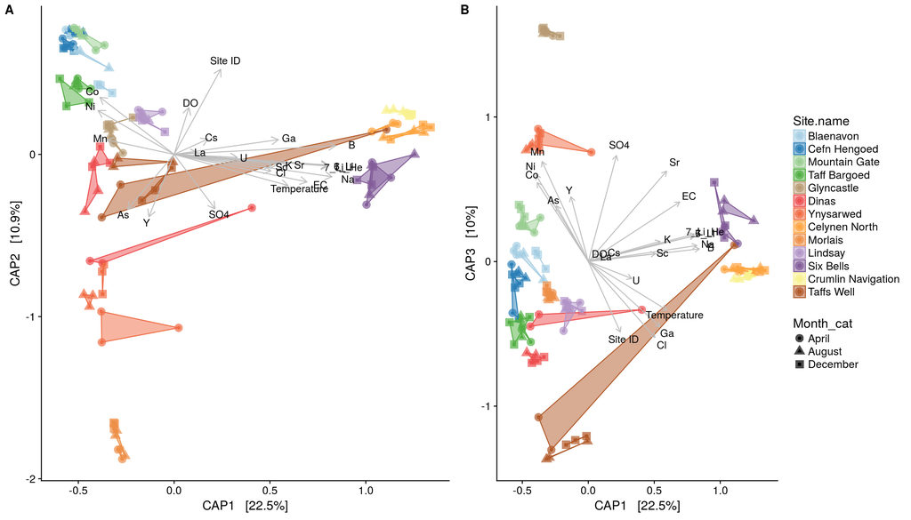

```r
ps.b.r.CAP_norm_sig.plot
```

So, as previously seen, two major groups composed of high-S and high-Fe samples. It *seems* DO and SO4 drive community structure in opposite ways. Also, temperature seems to play a role in defining high-S sample groups.

Is this ordination’s goodness of fit better than random models? i.e. are the constraints in this model significant?

```r
anova(CAP_ps_cap_r_norm, perm=1e3)
```

```
## Permutation test for capscale under reduced model
## Permutation: free
## Number of permutations: 999
##
## Model: capscale(formula = distance ~ Site.ID + Temp.C + EC.uS.cm + DO..sat + K.µg.ml + Na.µg.ml + Cl..µg.ml + SO4..µg.ml + X6.Li.ng.ml + X7.Li.ng.ml + X7.Li..He..ng.ml + X11.B.ng.ml + X45.Sc.ng.ml + X55.Mn.ng.ml + X59.Co.ng.ml + X60.Ni.ng.ml + X69.Ga.ng.ml + X75.As..He..ng.ml + X88.Sr.ng.ml + X89…
##          Df SumOfSqs      F Pr(>F)
## Model    23  17.5620 22.335  0.001 ***
## Residual 93   3.1794
## ---
## Signif. codes:  0 '***' 0.001 '**' 0.01 '*' 0.05 '.' 0.1 ' ' 1
```

As before, but now what microbial groups are influenced by these variables? More ordination on the way.

```r
ps_cap_r_norm_april = subset_samples(ps_cap_r_norm, Month_cat == "April")
ps_cap_r_norm_april_f = filter_taxa(ps_cap_r_norm_april, function(x) sum(x) > .01, TRUE)
ps_cap_r_norm_august = subset_samples(ps_cap_r_norm, Month_cat == "August")
ps_cap_r_norm_august_f = filter_taxa(ps_cap_r_norm_august, function(x) sum(x) > .01, TRUE)
ps_cap_r_norm_december = subset_samples(ps_cap_r_norm, Month_cat == "December")
ps_cap_r_norm_december_f = filter_taxa(ps_cap_r_norm_december, function(x) sum(x) > .01, TRUE)

CAP_norm_ps_cap_r_norm_april_f <- ordinate(ps_cap_r_norm_april_f,
                           method = "CAP",
                           distance = "jsd",
                           k=3, trymax=1e3, weighted=TRUE,
                           formula = ~ Site.ID + Temp.C + EC.uS.cm + DO..sat + K.µg.ml + Na.µg.ml + Cl..µg.ml + SO4..µg.ml + X6.Li.ng.ml + X7.Li.ng.ml + X7.Li..He..ng.ml + X11.B.ng.ml + X45.Sc.ng.ml + X55.Mn.ng.ml + X59.Co.ng.ml + X60.Ni.ng.ml + X69.Ga.ng.ml + X75.As..He..ng.ml + X88.Sr.ng.ml + X89.Y.ng.ml + X133.Cs.ng.ml + X139.La.ng.ml + X238.U.ng.ml)

CAP_norm_ps_cap_r_norm_august_f <- ordinate(ps_cap_r_norm_august_f,
                           method = "CAP",
                           distance = "jsd",
                           k=3, trymax=1e3, weighted=TRUE,
                           formula = ~ Site.ID + Temp.C + EC.uS.cm + DO..sat + K.µg.ml + Na.µg.ml + Cl..µg.ml + SO4..µg.ml + X6.Li.ng.ml + X7.Li.ng.ml + X7.Li..He..ng.ml + X11.B.ng.ml + X45.Sc.ng.ml + X55.Mn.ng.ml + X59.Co.ng.ml + X60.Ni.ng.ml + X69.Ga.ng.ml + X75.As..He..ng.ml + X88.Sr.ng.ml + X89.Y.ng.ml + X133.Cs.ng.ml + X139.La.ng.ml + X238.U.ng.ml)

CAP_norm_ps_cap_r_norm_december_f <- ordinate(ps_cap_r_norm_december_f,
                           method = "CAP",
                           distance = "jsd",
                           k=3, trymax=1e3, weighted=TRUE,
                           formula = ~ Site.ID + Temp.C + EC.uS.cm + DO..sat + K.µg.ml + Na.µg.ml + Cl..µg.ml + SO4..µg.ml + X6.Li.ng.ml + X7.Li.ng.ml + X7.Li..He..ng.ml + X11.B.ng.ml + X45.Sc.ng.ml + X55.Mn.ng.ml + X59.Co.ng.ml + X60.Ni.ng.ml + X69.Ga.ng.ml + X75.As..He..ng.ml + X88.Sr.ng.ml + X89.Y.ng.ml + X133.Cs.ng.ml + X139.La.ng.ml + X238.U.ng.ml)

#april
arrowmat_CAP_norm_taxa_april <- vegan::scores(CAP_norm_ps_cap_r_norm_april_f, display = "bp")
arrowmat_CAP_norm_taxa_april<-arrowmat_CAP_norm_taxa_april[!grepl("Site.name", rownames(arrowmat_CAP_norm_taxa_april)),]
arrowmat_CAP_norm_taxa_april<-arrowmat_CAP_norm_taxa_april[!grepl("Month_cat", rownames(arrowmat_CAP_norm_taxa_april)),]
rownames(arrowmat_CAP_norm_taxa_april) <- c("Site ID","Temperature","EC","DO","K","Na","Cl","SO4","6_Li","7_Li","7_Li_He",
                                               "B","Sc","Mn","Co","Ni","Ga","As","Sr","Y","Cs","La","U")
arrowdf_CAP_norm_taxa_april <- data.frame(labels = rownames(arrowmat_CAP_norm_taxa_april), arrowmat_CAP_norm_taxa_april)
arrow_map_CAP_norm_taxa_april <- aes(xend = CAP1, yend = CAP2,
                     x = 0, y = 0,
                     shape = NULL, color = NULL,
                     label = labels)
label_map_CAP_norm_taxa_april <- aes(x = 1.1 * CAP1, y = 1.1 * CAP2,
                     shape = NULL, color = NULL,
                     label = labels)
arrowhead_CAP_norm_taxa_april = arrow(length = unit(0.02, "npc"))

april_phyla=nrow(as.data.frame(table(tax_table(ps_cap_r_norm_april_f)[, "Phylum"], exclude = NULL)))

CAP_labels_april <- plot_ordination(ps_cap_r_norm_april_f,
                                    ordination = CAP_norm_ps_cap_r_norm_april_f,
                                    axes = c(1,2), type="taxa")
CAP_april_xlabel <- CAP_labels_april$labels$x
CAP_april_ylabel <- CAP_labels_april$labels$y

CAP_norm_april_taxa_sig_plot_a12 <- plot_ordination(ps_cap_r_norm_april_f,
                                    ordination = CAP_norm_ps_cap_r_norm_april_f,
                                    axes = c(1,2), type="taxa", justDF = TRUE)
CAP_norm_april_taxa_sig_plot_a12$Phylum=as.character(CAP_norm_april_taxa_sig_plot_a12$Phylum)
CAP_norm_april_taxa_sig_plot_a12$Class=as.character(CAP_norm_april_taxa_sig_plot_a12$Class)

ov_CAP_norm_april_taxa_sig_plot_a12<-subset(CAP_norm_april_taxa_sig_plot_a12,
                           Phylum != "Proteobacteria")
ov_CAP_norm_april_taxa_sig_plot_a12$Phylum=as.character(ov_CAP_norm_april_taxa_sig_plot_a12$Phylum)

class_ov_CAP_norm_april_taxa_sig_plot_a12<-subset(CAP_norm_april_taxa_sig_plot_a12,
                           Class %in% c("Epsilonproteobacteria","Betaproteobacteria","Gammaproteobacteria","Deltaproteobacteria"))
class_ov_CAP_norm_april_taxa_sig_plot_a12$Class=as.character(class_ov_CAP_norm_april_taxa_sig_plot_a12$Class)

april_class <- length(unique(class_ov_CAP_norm_april_taxa_sig_plot_a12$Class))

final_CAP_norm_april_taxa_sig_plot_a12 = ggplot(data=CAP_norm_april_taxa_sig_plot_a12,
                                                aes(x=CAP1,y=CAP2)) +
  geom_point(data=ov_CAP_norm_april_taxa_sig_plot_a12,
             aes(x=CAP1, y=CAP2,
                 color = Phylum, size = 4)) +
  geom_point(data = class_ov_CAP_norm_april_taxa_sig_plot_a12,
             aes(x=CAP1, y=CAP2,
                 color = Phylum,
                 shape = Class,
                 alpha = 1, size = 4)) +
  geom_segment(mapping = arrow_map_CAP_norm_taxa_april, size = .5,
               data = arrowdf_CAP_norm_taxa_april,
               color = "black", arrow = arrowhead_CAP_norm_taxa_april) +
  geom_text(mapping = label_map_CAP_norm_taxa_april, size = 5, fontface="bold",
            data = arrowdf_CAP_norm_taxa_april, show.legend = FALSE,
            check_overlap = TRUE) +
  scale_color_manual(values = colorRampPalette(brewer.pal(12, "Paired"))(25),
                     na.value = "black") +
  scale_fill_manual(values = colorRampPalette(brewer.pal(12, "Paired"))(25),
                    na.value = "black")  +
  scale_shape_manual(values=c(15, 17, 18, 4)) +
  guides(fill = FALSE,
         size = FALSE,
         alpha = FALSE,
         color = guide_legend(nrow = april_phyla/2),
         shape = guide_legend(nrow = april_phyla/2)) +
  labs(subtitle = "Using all SVs above 1% relative abundance",
       title= "April",
       x = CAP_april_xlabel,
       y = CAP_april_ylabel) +
  theme(plot.title = element_text(hjust = 0.5),
        legend.text = element_text(size = 12),
        legend.title = element_text(size = 13, face = "bold"),
        legend.position = "right",
        legend.direction = "vertical",
        legend.box.margin = margin(100, 6, 6, 6))
```

```r
#august
arrowmat_CAP_norm_taxa_august <- vegan::scores(CAP_norm_ps_cap_r_norm_august_f, display = "bp")
arrowmat_CAP_norm_taxa_august<-arrowmat_CAP_norm_taxa_august[!grepl("Site.name", rownames(arrowmat_CAP_norm_taxa_august)),]
arrowmat_CAP_norm_taxa_august<-arrowmat_CAP_norm_taxa_august[!grepl("Month_cat", rownames(arrowmat_CAP_norm_taxa_august)),]
rownames(arrowmat_CAP_norm_taxa_august) <- c("Site ID","Temperature","EC","DO","K","Na","Cl","SO4","6_Li","7_Li","7_Li_He",
                                               "B","Sc","Mn","Co","Ni","Ga","As","Sr","Y","Cs","La","U")
arrowdf_CAP_norm_taxa_august <- data.frame(labels = rownames(arrowmat_CAP_norm_taxa_august), arrowmat_CAP_norm_taxa_august)
arrow_map_CAP_norm_taxa_august <- aes(xend = CAP1, yend = CAP2,
                     x = 0, y = 0,
                     shape = NULL, color = NULL,
                     label = labels)
label_map_CAP_norm_taxa_august <- aes(x = 1.1 * CAP1, y = 1.1 * CAP2,
                     shape = NULL, color = NULL,
                     label = labels)
arrowhead_CAP_norm_taxa_august = arrow(length = unit(0.02, "npc"))

august_phyla=nrow(as.data.frame(table(tax_table(ps_cap_r_norm_august_f)[, "Phylum"], exclude = NULL)))

CAP_labels_august <- plot_ordination(ps_cap_r_norm_august_f,
                                    ordination = CAP_norm_ps_cap_r_norm_august_f,
                                    axes = c(1,2), type="taxa")
CAP_august_xlabel <- CAP_labels_august$labels$x
CAP_august_ylabel <- CAP_labels_august$labels$y

CAP_norm_august_taxa_sig_plot_a12 <- plot_ordination(ps_cap_r_norm_august_f,
                                    ordination = CAP_norm_ps_cap_r_norm_august_f,
                                    axes = c(1,2), type="taxa", justDF = TRUE)
CAP_norm_august_taxa_sig_plot_a12$Phylum=as.character(CAP_norm_august_taxa_sig_plot_a12$Phylum)
CAP_norm_august_taxa_sig_plot_a12$Class=as.character(CAP_norm_august_taxa_sig_plot_a12$Class)

ov_CAP_norm_august_taxa_sig_plot_a12<-subset(CAP_norm_august_taxa_sig_plot_a12,
                           Phylum != "Proteobacteria")
ov_CAP_norm_august_taxa_sig_plot_a12$Phylum=as.character(ov_CAP_norm_august_taxa_sig_plot_a12$Phylum)

class_ov_CAP_norm_august_taxa_sig_plot_a12<-subset(CAP_norm_august_taxa_sig_plot_a12,
                           Class %in% c("Epsilonproteobacteria","Betaproteobacteria","Gammaproteobacteria","Deltaproteobacteria"))
class_ov_CAP_norm_august_taxa_sig_plot_a12$Class=as.character(class_ov_CAP_norm_august_taxa_sig_plot_a12$Class)

august_class <- length(unique(class_ov_CAP_norm_august_taxa_sig_plot_a12$Class))

final_CAP_norm_august_taxa_sig_plot_a12 = ggplot(data=CAP_norm_august_taxa_sig_plot_a12,
                                                aes(x=CAP1,y=CAP2)) +
  geom_point(data=ov_CAP_norm_august_taxa_sig_plot_a12,
             aes(x=CAP1, y=CAP2,
                 color = Phylum, size = 4)) +
  geom_point(data = class_ov_CAP_norm_august_taxa_sig_plot_a12,
             aes(x=CAP1, y=CAP2,
                 color = Phylum,
                 shape = Class,
                 alpha = 1, size = 4)) +
  geom_segment(mapping = arrow_map_CAP_norm_taxa_august, size = .5,
               data = arrowdf_CAP_norm_taxa_august,
               color = "black", arrow = arrowhead_CAP_norm_taxa_august) +
  geom_text(mapping = label_map_CAP_norm_taxa_august, size = 5, fontface="bold",
            data = arrowdf_CAP_norm_taxa_august, show.legend = FALSE,
            check_overlap = TRUE) +
  scale_color_manual(values = colorRampPalette(brewer.pal(12, "Paired"))(23),
                     na.value = "black") +
  scale_fill_manual(values = colorRampPalette(brewer.pal(12, "Paired"))(23),
                    na.value = "black")  +
  scale_shape_manual(values=c(15, 17, 18, 4)) +
  guides(fill = FALSE,
         color = guide_legend(nrow= august_phyla/2),
         size = FALSE,
         alpha = FALSE,
         shape = guide_legend(nrow = august_phyla/2)) +
  labs(title= "August",
       x = CAP_august_xlabel,
       y = CAP_august_ylabel) +
  theme(plot.title = element_text(hjust = 0.5),
        legend.text = element_text(size = 12),
        legend.title = element_text(size = 13, face = "bold"),
        legend.position = "right",
        legend.direction = "vertical",
        legend.box.margin = margin(100, 6, 6, 6))

#december
arrowmat_CAP_norm_taxa_december <- vegan::scores(CAP_norm_ps_cap_r_norm_december_f, display = "bp")
arrowmat_CAP_norm_taxa_december<-arrowmat_CAP_norm_taxa_december[!grepl("Site.name", rownames(arrowmat_CAP_norm_taxa_december)),]
arrowmat_CAP_norm_taxa_december<-arrowmat_CAP_norm_taxa_december[!grepl("Month_cat", rownames(arrowmat_CAP_norm_taxa_december)),]
rownames(arrowmat_CAP_norm_taxa_december) <- c("Site ID","Temperature","EC","DO","K","Na","Cl","SO4","6_Li","7_Li","7_Li_He",
                                               "B","Sc","Mn","Co","Ni","Ga","As","Sr","Y","Cs","La","U")
arrowdf_CAP_norm_taxa_december <- data.frame(labels = rownames(arrowmat_CAP_norm_taxa_december), arrowmat_CAP_norm_taxa_december)
arrow_map_CAP_norm_taxa_december <- aes(xend = CAP1, yend = CAP2,
                     x = 0, y = 0,
                     shape = NULL, color = NULL,
                     label = labels)
label_map_CAP_norm_taxa_december <- aes(x = 1.1 * CAP1, y = 1.1 * CAP2,
                     shape = NULL, color = NULL,
                     label = labels)
arrowhead_CAP_norm_taxa_december = arrow(length = unit(0.02, "npc"))

december_phyla=nrow(as.data.frame(table(tax_table(ps_cap_r_norm_december_f)[, "Phylum"], exclude = NULL)))

CAP_labels_december <- plot_ordination(ps_cap_r_norm_december_f,
                                    ordination = CAP_norm_ps_cap_r_norm_december_f,
                                    axes = c(1,2), type="taxa")
CAP_december_xlabel <- CAP_labels_december$labels$x
CAP_december_ylabel <- CAP_labels_december$labels$y

CAP_norm_december_taxa_sig_plot_a12 <- plot_ordination(ps_cap_r_norm_december_f,
                                    ordination = CAP_norm_ps_cap_r_norm_december_f,
                                    axes = c(1,2), type="taxa", justDF = TRUE)
CAP_norm_december_taxa_sig_plot_a12$Phylum=as.character(CAP_norm_december_taxa_sig_plot_a12$Phylum)
CAP_norm_december_taxa_sig_plot_a12$Class=as.character(CAP_norm_december_taxa_sig_plot_a12$Class)
```

```r
ov_CAP_norm_december_taxa_sig_plot_a12<-subset(CAP_norm_december_taxa_sig_plot_a12,
                           Phylum != "Proteobacteria")
ov_CAP_norm_december_taxa_sig_plot_a12$Phylum=as.character(ov_CAP_norm_december_taxa_sig_plot_a12$Phylum)

class_ov_CAP_norm_december_taxa_sig_plot_a12<-subset(CAP_norm_december_taxa_sig_plot_a12,
                           Class %in% c("Epsilonproteobacteria","Betaproteobacteria","Gammaproteobacteria","Deltaproteobacteria"))
class_ov_CAP_norm_december_taxa_sig_plot_a12$Class=as.character(class_ov_CAP_norm_december_taxa_sig_plot_a12$Class)

december_class <- length(unique(class_ov_CAP_norm_december_taxa_sig_plot_a12$Class))

final_CAP_norm_december_taxa_sig_plot_a12 = ggplot(data=CAP_norm_december_taxa_sig_plot_a12,
                                                aes(x=CAP1,y=CAP2)) +
  geom_point(data=ov_CAP_norm_december_taxa_sig_plot_a12,
             aes(x=CAP1, y=CAP2,
                 color = Phylum, size = 4)) +
  geom_point(data = class_ov_CAP_norm_december_taxa_sig_plot_a12,
             aes(x=CAP1, y=CAP2,
                 color = Phylum,
                 shape = Class,
                 alpha = 1, size = 4)) +
  geom_segment(mapping = arrow_map_CAP_norm_taxa_december, size = .5,
               data = arrowdf_CAP_norm_taxa_december,
               color = "black", arrow = arrowhead_CAP_norm_taxa_december) +
  geom_text(mapping = label_map_CAP_norm_taxa_december, size = 5, fontface="bold",
            data = arrowdf_CAP_norm_taxa_december, show.legend = FALSE,
            check_overlap = TRUE) +
  scale_color_manual(values = colorRampPalette(brewer.pal(12, "Paired"))(27),
                     na.value = "black") +
  scale_fill_manual(values = colorRampPalette(brewer.pal(12, "Paired"))(27),
                    na.value = "black")  +
  scale_shape_manual(values=c(15, 17, 18, 4)) +
  guides(fill = FALSE,
         color = guide_legend(nrow = december_phyla/2),
         size = FALSE,
         alpha = FALSE,
         shape = guide_legend(nrow = december_phyla/2)) +
  labs(title= "December",
       x = CAP_december_xlabel,
       y = CAP_december_ylabel) +
  theme(plot.title = element_text(hjust = 0.5),
        legend.text = element_text(size = 12),
        legend.title = element_text(size = 13, face = "bold"),
        legend.position = "right",
        legend.direction = "vertical",
        legend.box.margin = margin(100, 6, 6, 6))

ps_cap_r_norm_Month_cat<-plot_grid(final_CAP_norm_april_taxa_sig_plot_a12,
                                   final_CAP_norm_august_taxa_sig_plot_a12,
                                   final_CAP_norm_december_taxa_sig_plot_a12,
                                   align = 'v', ncol = 1)
```

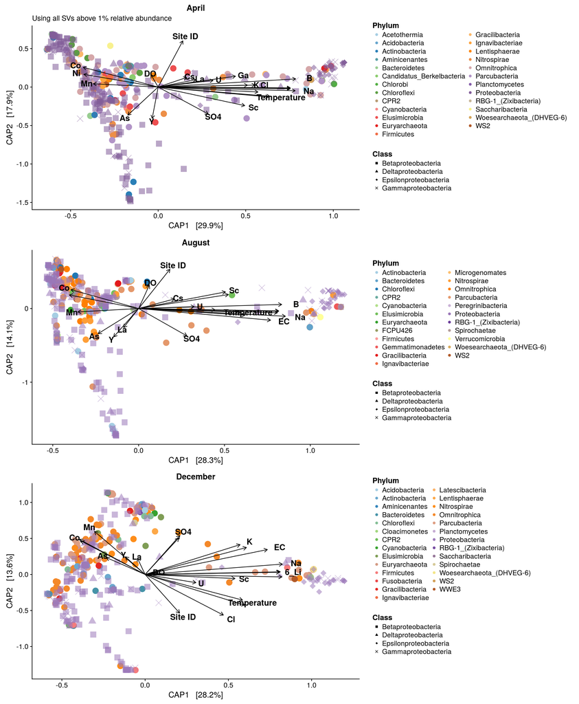

```r
ps_cap_r_norm_Month_cat
```